# Point Pattern Analysis - distance of Enteric Fever and Leptospirosis in Kelantan

Hazlienor

2023-04-12

## Load library

```r
library(sf)
library(tidyverse)
library(here)
library(janitor)
```

```r
library(gtsummary)
library(DT)
library(stringr)
library(readxl)
library(broom)
library(tmap)
library(mapview)
library(lubridate)
library(maptools)
library(spatstat)
library(spdep)
library(gridExtra)
library(grid)
library(sparr)
library(spatialEco)
```

## Prepare data

read polygon data

```r
kel <- st_read(here("Map",
                    "kelantan.shp"))
```

read population data per mukim per year

```r
kel_mukim <- read_xlsx(here ("mukim.xlsx"))
```

merge population data to polygon

```r
kel_map <- merge(kel,kel_mukim,by.x="MUKIM", by.y="MUKIM", all.x=T, sort=F)
dim(kel_map)
```

```
## [1] 66 49
```

```r
class(kel_map)
```

```
## [1] "sf"         "data.frame"
```

```r
st_crs(kel_map)
```

```
## Coordinate Reference System:
##   User input: Kertau (RSO) / RSO Malaya (m)
##   wkt:
## PROJCRS["Kertau (RSO) / RSO Malaya (m)",
##     BASEGEOGCRS["Kertau (RSO)",
##         DATUM["Kertau (RSO)",
##             ELLIPSOID["Everest 1830 (RSO 1969)",6377295.664,300.8017,
##                 LENGTHUNIT["metre",1]]],
##         PRIMEM["Greenwich",0,
##             ANGLEUNIT["degree",0.0174532925199433]],
##         ID["EPSG",4751]],
##     CONVERSION["Rectified Skew Orthomorphic Malaya Grid (metres)",
##         METHOD["Hotine Oblique Mercator (variant A)",
##             ID["EPSG",9812]],
##         PARAMETER["Latitude of projection centre",4,
##             ANGLEUNIT["degree",0.0174532925199433],
##             ID["EPSG",8811]],
##         PARAMETER["Longitude of projection centre",102.25,
##             ANGLEUNIT["degree",0.0174532925199433],
##             ID["EPSG",8812]],
##         PARAMETER["Azimuth of initial line",323.0257905,
##             ANGLEUNIT["degree",0.0174532925199433],
##             ID["EPSG",8813]],
##         PARAMETER["Angle from Rectified to Skew Grid",323.130102361111,
##             ANGLEUNIT["degree",0.0174532925199433],
##             ID["EPSG",8814]],
##         PARAMETER["Scale factor on initial line",0.99984,
##             SCALEUNIT["unity",1],
##             ID["EPSG",8815]],
##         PARAMETER["False easting",804670.24,
##             LENGTHUNIT["metre",1],
##             ID["EPSG",8806]],
##         PARAMETER["False northing",0,
##             LENGTHUNIT["metre",1],
##             ID["EPSG",8807]]],
##     CS[Cartesian,2],
##         AXIS["(E)",east,
##             ORDER[1],
##             LENGTHUNIT["metre",1]],
##         AXIS["(N)",north,
##             ORDER[2],
##             LENGTHUNIT["metre",1]],
##     USAGE[
##         SCOPE["Engineering survey, topographic mapping."],
##         AREA["Malaysia - West Malaysia onshore."],
##         BBOX[1.21,99.59,6.72,104.6]],
##     ID["EPSG",3168]]
```

load disease data in xlxs

```r
linelist <- read_xlsx(here ("linelist.xlsx")) %>% clean_names()
glimpse(linelist)
```

```
## Rows: 1,318
## Columns: 26
## $ diagnosis                                  <chr> "Leptospirosis", "Leptospir…
## $ notifikasi_no                              <dbl> 2685725, 2728504, 2739963, …
## $ tahun_daftar                               <dbl> 2016, 2016, 2016, 2016, 201…
## $ epid_daftar                                <dbl> 6, 9, 11, 12, 18, 18, 19, 1…
## $ age                                        <dbl> 30, 23, 39, 43, 31, 34, 48,…
## $ alamat_semasa_kejadian                     <chr> "FELDA ARING", "LADANG U&I …
## $ poskod                                     <dbl> 18300, 18300, 18300, 18300,…
## $ latitude_rso                               <dbl> 478031, 459494, 441802, 488…
## $ longitude_rso                              <dbl> 548141, 564966, 547551, 547…
## $ latitude_wgs                               <dbl> 4.944824, 5.034372, 4.89743…
## $ longitude_wgs                              <dbl> 102.3491, 102.1477, 101.960…
## $ notifikasi_status                          <chr> "Daftar Kes", "Daftar Kes",…
## $ race                                       <chr> "Foreigner", "Foreigner", "…
## $ kewarganegaraan                            <chr> "Bukan Warganegara", "Bukan…
## $ gender                                     <chr> "Male", "Male", "Male", "Ma…
## $ nationality                                <chr> "INDONESIA", "INDONESIA", "…
## $ klasifikasi_kes                            <chr> "Sporadic", "Sporadic", "Sp…
## $ cara_pengesanan_kes                        <chr> "Pasif", "Pasif", "Pasif", …
## $ jenis_rawatan                              <chr> "Wad Perubatan", "Jabatan K…
## $ daerah                                     <chr> "GUA MUSANG", "GUA MUSANG",…
## $ mukim                                      <chr> "CHIKU", "CHIKU", "GALAS", …
## $ lokaliti                                   <chr> NA, "LADANG U & I, CIKU", "…
## $ diagnosis2                                 <chr> "LEPTOSPIROSIS", "LEPTOSPIR…
## $ sub_diagnosis                              <chr> NA, NA, NA, NA, NA, NA, NA,…
## $ negeri                                     <chr> "KELANTAN", "KELANTAN", "KE…
## $ jenis_import_jangkitan_dalam_negara_negeri <chr> NA, NA, NA, NA, NA, NA, NA,…
```

remove na coordinate

```r
#disease data all - list all is all leptospirosis and enteric fever cases
listALL <- linelist %>%
  filter(!is.na(latitude_wgs),
         !is.na(longitude_wgs))
```

convert all disease data to spatial data

```r
loc_ALL <- st_as_sf(listALL,
                    coords = c("longitude_wgs", "latitude_wgs"),
                    crs = 4326)
```

convert CRS to RSO

```r
loc_ALL2 <- st_transform(loc_ALL, 3168)
```

# Transform data

convert data to spatial format

```r
kel_map.sp <- as(kel_map, "Spatial")
class(kel_map.sp)
```

```
## [1] "SpatialPolygonsDataFrame"
## attr(,"package")
## [1] "sp"
```

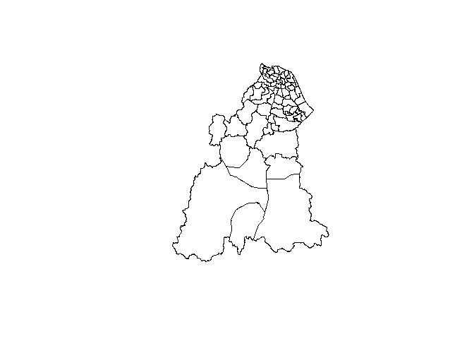

```r
plot(kel_map.sp)
```

convert point to spatial

```r
loc_ALL2.sp <- as(loc_ALL2, "Spatial")
class(loc_ALL2.sp)
```

```
## [1] "SpatialPointsDataFrame"
## attr(,"package")
## [1] "sp"
```

select point only in Kelantan

```r
all_kel <- loc_ALL2 %>%
  mutate(within_kel_map = lengths(st_within(loc_ALL2, kel_map)))
all_kel2 <- all_kel %>%
  filter(within_kel_map == 1)
```

split data by diagnosis

```r
Enteric_kel <- all_kel2 %>%
  filter(diagnosis == "Enteric_fever")
lepto_kel <- all_kel2 %>%
  filter(diagnosis == "Leptospirosis")
```

convert enteric fever and lepto pint data to spatial to ppp

```r
Enteric_kel.sp <- as(Enteric_kel, "Spatial")
Enteric_kel.ppp <- as(Enteric_kel.sp, 'ppp')
lepto_kel.sp <- as(lepto_kel, "Spatial")
lepto_kel.ppp <- as(lepto_kel.sp, 'ppp')
```

# Enteric fever data by year

extract enteric fever by year

```r
loc_ent16 <- subset(Enteric_kel, tahun_daftar=="2016")
loc_ent17 <- subset(Enteric_kel, tahun_daftar=="2017")
loc_ent18 <- subset(Enteric_kel, tahun_daftar=="2018")
loc_ent19 <- subset(Enteric_kel, tahun_daftar=="2019")
loc_ent20 <- subset(Enteric_kel, tahun_daftar=="2020")
loc_ent21 <- subset(Enteric_kel, tahun_daftar=="2021")
loc_ent22 <- subset(Enteric_kel, tahun_daftar=="2022")
```

convert point to spatial

```r
loc_ent16.sp <- as(loc_ent16, "Spatial")
loc_ent17.sp <- as(loc_ent17, "Spatial")
loc_ent18.sp <- as(loc_ent18, "Spatial")
loc_ent19.sp <- as(loc_ent19, "Spatial")
loc_ent20.sp <- as(loc_ent20, "Spatial")
loc_ent21.sp <- as(loc_ent21, "Spatial")
loc_ent22.sp <- as(loc_ent22, "Spatial")
```

convert point spatial data to ppp format

```r
loc_ALL2.ppp <- as(loc_ALL2.sp, 'ppp')
class(loc_ALL2.ppp)
```

```
## [1] "ppp"
```

```r
loc_ent16.ppp <- as(loc_ent16.sp, 'ppp')
loc_ent17.ppp <- as(loc_ent17.sp, 'ppp')
loc_ent18.ppp <- as(loc_ent18.sp, 'ppp')
loc_ent19.ppp <- as(loc_ent19.sp, 'ppp')
loc_ent20.ppp <- as(loc_ent20.sp, 'ppp')
loc_ent21.ppp <- as(loc_ent21.sp, 'ppp')
loc_ent22.ppp <- as(loc_ent22.sp, 'ppp')
```

transform to owin format

```r
kel_map.owin <- as(kel_map.sp, "owin")
class(kel_map.owin)
```

```
## [1] "owin"
```

plot ppp object with window

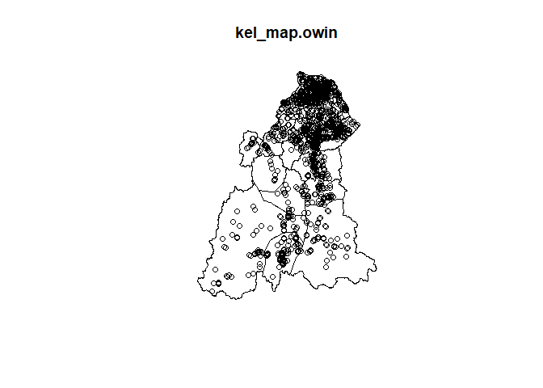

```r
# plot ALL
plot(kel_map.owin)
points(loc_ALL2.ppp)
```

Remove marks

```r
# remove marks enteric fever 2016-2022
Enteric_kel.ppp2 <- Enteric_kel.ppp
marks(Enteric_kel.ppp2) <- NULL

# remove marks (year)
loc_ent16.ppp2 <- loc_ent16.ppp
marks(loc_ent16.ppp2) <- NULL
loc_ent17.ppp2 <- loc_ent17.ppp
marks(loc_ent17.ppp2) <- NULL
loc_ent18.ppp2 <- loc_ent18.ppp
marks(loc_ent18.ppp2) <- NULL
loc_ent19.ppp2 <- loc_ent19.ppp
marks(loc_ent19.ppp2) <- NULL
loc_ent20.ppp2 <- loc_ent20.ppp
marks(loc_ent20.ppp2) <- NULL
loc_ent21.ppp2 <- loc_ent21.ppp
marks(loc_ent21.ppp2) <- NULL
loc_ent22.ppp2 <- loc_ent22.ppp
marks(loc_ent22.ppp2) <- NULL
```

generate window

```r
Window(Enteric_kel.ppp2) <- kel_map.owin
Window(loc_ent16.ppp2) <- kel_map.owin
Window(loc_ent17.ppp2) <- kel_map.owin
Window(loc_ent18.ppp2) <- kel_map.owin
Window(loc_ent19.ppp2) <- kel_map.owin
Window(loc_ent20.ppp2) <- kel_map.owin
Window(loc_ent21.ppp2) <- kel_map.owin
Window(loc_ent22.ppp2) <- kel_map.owin
```

rescale to km

```r
# point
Enteric_kel.ppp2.km <- rescale(Enteric_kel.ppp2, 1000, 'km') #cumulative
loc_ent16.ppp2.km <- rescale(loc_ent16.ppp2, 1000, 'km') #2016
loc_ent17.ppp2.km <- rescale(loc_ent17.ppp2, 1000, 'km') #2017
loc_ent18.ppp2.km <- rescale(loc_ent18.ppp2, 1000, 'km') #2018
loc_ent19.ppp2.km <- rescale(loc_ent19.ppp2, 1000, 'km') #2019
loc_ent20.ppp2.km <- rescale(loc_ent20.ppp2, 1000, 'km') #2020
loc_ent21.ppp2.km <- rescale(loc_ent21.ppp2, 1000, 'km') #2021
loc_ent22.ppp2.km <- rescale(loc_ent22.ppp2, 1000, 'km') #2022

# map
kel_map.owin.km <- rescale(kel_map.owin, 1000, 'km')
```

# Leptospirosis data by year

extract leptospirosis by year, convert to ppp

```r
loc_lep16 <- subset(lepto_kel, tahun_daftar=="2016")
loc_lep17 <- subset(lepto_kel, tahun_daftar=="2017")
loc_lep18 <- subset(lepto_kel, tahun_daftar=="2018")
loc_lep19 <- subset(lepto_kel, tahun_daftar=="2019")
loc_lep20 <- subset(lepto_kel, tahun_daftar=="2020")
loc_lep21 <- subset(lepto_kel, tahun_daftar=="2021")
loc_lep22 <- subset(lepto_kel, tahun_daftar=="2022")
```

convert point to spatial

```r
loc_lep16.sp <- as(loc_lep16, "Spatial")
loc_lep17.sp <- as(loc_lep17, "Spatial")
loc_lep18.sp <- as(loc_lep18, "Spatial")
loc_lep19.sp <- as(loc_lep19, "Spatial")
loc_lep20.sp <- as(loc_lep20, "Spatial")
loc_lep21.sp <- as(loc_lep21, "Spatial")
loc_lep22.sp <- as(loc_lep22, "Spatial")
```

convert point spatial data to ppp format

```r
loc_lep16.ppp <- as(loc_lep16.sp, 'ppp')
loc_lep17.ppp <- as(loc_lep17.sp, 'ppp')
loc_lep18.ppp <- as(loc_lep18.sp, 'ppp')
loc_lep19.ppp <- as(loc_lep19.sp, 'ppp')
loc_lep20.ppp <- as(loc_lep20.sp, 'ppp')
loc_lep21.ppp <- as(loc_lep21.sp, 'ppp')
loc_lep22.ppp <- as(loc_lep22.sp, 'ppp')
```

remove marks

```r
#remove marks leptospirosis 2016-2022
lepto_kel.ppp2 <- lepto_kel.ppp
marks(lepto_kel.ppp2) <- NULL

#remove marks (year)
loc_lep16.ppp2 <- loc_lep16.ppp
marks(loc_lep16.ppp2) <- NULL
loc_lep17.ppp2 <- loc_lep17.ppp
marks(loc_lep17.ppp2) <- NULL
loc_lep18.ppp2 <- loc_lep18.ppp
marks(loc_lep18.ppp2) <- NULL
loc_lep19.ppp2 <- loc_lep19.ppp
marks(loc_lep19.ppp2) <- NULL
loc_lep20.ppp2 <- loc_lep20.ppp
marks(loc_lep20.ppp2) <- NULL
loc_lep21.ppp2 <- loc_lep21.ppp
marks(loc_lep21.ppp2) <- NULL
loc_lep22.ppp2 <- loc_lep22.ppp
marks(loc_lep22.ppp2) <- NULL
```

generate window

```r
Window(lepto_kel.ppp2) <- kel_map.owin
Window(loc_lep16.ppp2) <- kel_map.owin
Window(loc_lep17.ppp2) <- kel_map.owin
Window(loc_lep18.ppp2) <- kel_map.owin
Window(loc_lep19.ppp2) <- kel_map.owin
Window(loc_lep20.ppp2) <- kel_map.owin
Window(loc_lep21.ppp2) <- kel_map.owin
Window(loc_lep22.ppp2) <- kel_map.owin
```

rescale to km

```r
#point
lepto_kel.ppp2.km <- rescale(lepto_kel.ppp2, 1000, 'km') #cumulative
loc_lep16.ppp2.km <- rescale(loc_lep16.ppp2, 1000, 'km') #2016
loc_lep17.ppp2.km <- rescale(loc_lep17.ppp2, 1000, 'km') #2017
loc_lep18.ppp2.km <- rescale(loc_lep18.ppp2, 1000, 'km') #2018
loc_lep19.ppp2.km <- rescale(loc_lep19.ppp2, 1000, 'km') #2019
loc_lep20.ppp2.km <- rescale(loc_lep20.ppp2, 1000, 'km') #2020
loc_lep21.ppp2.km <- rescale(loc_lep21.ppp2, 1000, 'km') #2021
loc_lep22.ppp2.km <- rescale(loc_lep22.ppp2, 1000, 'km') #2022

#map
kel_map.owin.km <- rescale(kel_map.owin, 1000, 'km')
```

## distance-based analysis for Enteric fever

# ANN for Enteric fever 2016-2022

```r
# extracts the intensity - average number of enteric fever per square kilometer)
ENTIntensity <- round(summary(Enteric_kel.ppp2.km)$intensity, 3)

# calculates the average nearest neighbor distance  in km
ENTANNkm <- round(mean(nndist(Enteric_kel.ppp2.km)), 2)

# calculates the average nearest neighbor distance  in m
ENTANN <- round(mean(nndist(Enteric_kel.ppp2)), 2)
```

Intensity by year

```r
ENT16_Intensity <- round(summary(loc_ent16.ppp2.km)$intensity, 3) #2016
ENT17_Intensity <- round(summary(loc_ent17.ppp2.km)$intensity, 3) #2017
ENT18_Intensity <- round(summary(loc_ent18.ppp2.km)$intensity, 3) #2018
ENT19_Intensity <- round(summary(loc_ent19.ppp2.km)$intensity, 3) #2019
ENT20_Intensity <- round(summary(loc_ent20.ppp2.km)$intensity, 3) #2020
ENT21_Intensity <- round(summary(loc_ent21.ppp2.km)$intensity, 3) #2021
ENT22_Intensity <- round(summary(loc_ent22.ppp2.km)$intensity, 3) #2022
```

average ANN in meter by year

```r
ENTANN16 <- round(mean(nndist(loc_ent16.ppp2)), 2)
ENTANN17 <- round(mean(nndist(loc_ent17.ppp2)), 2)
ENTANN18 <- round(mean(nndist(loc_ent18.ppp2)), 2)
ENTANN19 <- round(mean(nndist(loc_ent19.ppp2)), 2)
ENTANN20 <- round(mean(nndist(loc_ent20.ppp2)), 2)
ENTANN21 <- round(mean(nndist(loc_ent21.ppp2)), 2)
ENTANN22 <- round(mean(nndist(loc_ent22.ppp2)), 2)
```

interpret spatial intensity

```r
print(paste0("The average spatial intensity for Enteric Fever cases 2016-2022 is ", ENTIntensity, " cases per sq. km."))
```

```
## [1] "The average spatial intensity for Enteric Fever cases 2016-2022 is 0.014 cases per sq. km."
```

```r
print(paste0("The average spatial intensity for Enteric Fever cases 2016 is ", ENT16_Intensity, " cases per sq. km."))
```

```
## [1] "The average spatial intensity for Enteric Fever cases 2016 is 0.004 cases per sq. km."
```

```r
print(paste0("The average spatial intensity for Enteric Fever cases 2017 is ", ENT17_Intensity, " cases per sq. km."))
```

```
## [1] "The average spatial intensity for Enteric Fever cases 2017 is 0.003 cases per sq. km."
```

```r
print(paste0("The average spatial intensity for Enteric Fever cases 2018 is ", ENT18_Intensity, " cases per sq. km."))
```

```
## [1] "The average spatial intensity for Enteric Fever cases 2018 is 0.003 cases per sq. km."
```

```r
print(paste0("The average spatial intensity for Enteric Fever cases 2019 is ", ENT19_Intensity, " cases per sq. km."))
```

```
## [1] "The average spatial intensity for Enteric Fever cases 2019 is 0.001 cases per sq. km."
```

```r
print(paste0("The average spatial intensity for Enteric Fever cases 2020 is ", ENT20_Intensity, " cases per sq. km."))
```

```
## [1] "The average spatial intensity for Enteric Fever cases 2020 is 0.001 cases per sq. km."
```

```r
print(paste0("The average spatial intensity for Enteric Fever cases 2021 is ", ENT21_Intensity, " cases per sq. km."))
```

```
## [1] "The average spatial intensity for Enteric Fever cases 2021 is 0 cases per sq. km."
```

```r
print(paste0("The average spatial intensity for Enteric Fever cases 2022 is ", ENT22_Intensity, " cases per sq. km."))
```

```
## [1] "The average spatial intensity for Enteric Fever cases 2022 is 0.003 cases per sq. km."
```

Calculate nearest neigbour index (NNI) for enteric fever NNI < 1 clustered, >1 dispersed

```r
#interpret ANN
print(paste0("The mean nearest neighbor distance for Enteric Fever cases 2016-2022 is ", ENTANN, " m."))
```

```
## [1] "The mean nearest neighbor distance for Enteric Fever cases 2016-2022 is 1643.29 m."
```

```r
print(paste0("The mean nearest neighbor distance for Enteric Fever cases 2016 is ", ENTANN16, " m."))
```

```
## [1] "The mean nearest neighbor distance for Enteric Fever cases 2016 is 3835.69 m."
```

```r
print(paste0("The mean nearest neighbor distance for Enteric Fever cases 2016 is ", ENTANN17, " m."))
```

```
## [1] "The mean nearest neighbor distance for Enteric Fever cases 2016 is 4503.12 m."
```

```r
print(paste0("The mean nearest neighbor distance for Enteric Fever cases 2016 is ", ENTANN18, " m."))
```

```
## [1] "The mean nearest neighbor distance for Enteric Fever cases 2016 is 3864.86 m."
```

```r
print(paste0("The mean nearest neighbor distance for Enteric Fever cases 2016 is ", ENTANN19, " m."))
```

```
## [1] "The mean nearest neighbor distance for Enteric Fever cases 2016 is 7236.52 m."
```

```r
print(paste0("The mean nearest neighbor distance for Enteric Fever cases 2016 is ", ENTANN20, " m."))
```

```
## [1] "The mean nearest neighbor distance for Enteric Fever cases 2016 is 13351.71 m."
```

```r
print(paste0("The mean nearest neighbor distance for Enteric Fever cases 2016 is ", ENTANN21, " m."))
```

```
## [1] "The mean nearest neighbor distance for Enteric Fever cases 2016 is 14253.05 m."
```

```r
print(paste0("The mean nearest neighbor distance for Enteric Fever cases 2016 is ", ENTANN22, " m."))
```

```
## [1] "The mean nearest neighbor distance for Enteric Fever cases 2016 is 3565.69 m."
```

```r
nniENT <- nni(Enteric_kel)
nniENT16 <- nni(loc_ent16)
nniENT17 <-nni(loc_ent17)
nniENT18 <- nni(loc_ent18)
nniENT19 <-nni(loc_ent19)
nniENT20 <-nni(loc_ent20)
nniENT21 <-nni(loc_ent21)
nniENT22 <-nni(loc_ent22)
NNI_ENT <- bind_rows(
  data.frame(Dataset = "2016-2022", nniENT),
  data.frame(Dataset = "2016", nniENT16),
  data.frame(Dataset = "2017", nniENT17),
  data.frame(Dataset = "2018", nniENT18),
  data.frame(Dataset = "2019", nniENT19),
  data.frame(Dataset = "2020", nniENT20),
  data.frame(Dataset = "2021", nniENT21),
  data.frame(Dataset = "2022", nniENT22)
)
NNI_ENT
```

```
##     Dataset       NNI    z.score            p expected.mean.distance
## 1 2016-2022 0.5589368 -12.285691 1.081170e-34               2940.020
## 2      2016 0.9250764  -1.091599 2.750093e-01               4146.347
## 3      2017 0.8916706  -1.277524 2.014174e-01               5050.203
## 4      2018 0.7438140  -3.287702 1.010086e-03               5196.001
## 5      2019 1.2427335   1.737500 8.229904e-02               5823.063
## 6      2020 1.9445027   6.514870 7.275245e-11               6866.389
## 7      2021 2.6203292   6.931371 4.167812e-12               5439.413
## 8      2022 0.7972390  -2.422410 1.541795e-02               4472.549
##   observed.mean.distance
## 1               1643.285
## 2               3835.688
## 3               4503.117
## 4               3864.859
## 5               7236.516
## 6              13351.713
## 7              14253.052
## 8               3565.690
```

clark evans test for Enteric Fever -R less than 1 indicates spatial clustering. The smaller the value of R, the greater the degree of clustering.

```r
CE_ent <- clarkevans.test(Enteric_kel.ppp2)
CE_ent16 <- clarkevans.test(loc_ent16.ppp2)
CE_ent17 <- clarkevans.test(loc_ent17.ppp2)
CE_ent18 <- clarkevans.test(loc_ent18.ppp2)
CE_ent19 <- clarkevans.test(loc_ent19.ppp2)
CE_ent20 <- clarkevans.test(loc_ent20.ppp2)
CE_ent21 <- clarkevans.test(loc_ent21.ppp2)
CE_ent22 <- clarkevans.test(loc_ent22.ppp2)

# dataframe
CE_ent.df <- data.frame(Dataset = "Enteric_kel.ppp2",
                       TestStatistic = CE_ent$statistic,
                       PValue = CE_ent$p.value)
CE_ent16.df <- data.frame(Dataset = "loc_ent16.ppp2",
                       TestStatistic = CE_ent16$statistic,
                       PValue = CE_ent16$p.value)
CE_ent17.df <- data.frame(Dataset = "loc_ent17.ppp2",
                       TestStatistic = CE_ent17$statistic,
                       PValue = CE_ent17$p.value)
CE_ent18.df <- data.frame(Dataset = "loc_ent18.ppp2",
                       TestStatistic = CE_ent18$statistic,
                       PValue = CE_ent18$p.value)
CE_ent19.df <- data.frame(Dataset = "loc_ent19.ppp2",
                       TestStatistic = CE_ent19$statistic,
                       PValue = CE_ent19$p.value)
CE_ent20.df <- data.frame(Dataset = "loc_ent20.ppp2",
                       TestStatistic = CE_ent20$statistic,
                       PValue = CE_ent20$p.value)
CE_ent21.df <- data.frame(Dataset = "loc_ent21.ppp2",
                       TestStatistic = CE_ent21$statistic,
                       PValue = CE_ent21$p.value)
CE_ent22.df <- data.frame(Dataset = "loc_ent22.ppp2",
                       TestStatistic = CE_ent22$statistic,
                       PValue = CE_ent22$p.value)

#combine rows
CE_ENT <- bind_rows(
  data.frame(Dataset = "2016-2022", CE_ent.df),
  data.frame(Dataset = "2016", CE_ent16.df),
  data.frame(Dataset = "2017", CE_ent17.df),
  data.frame(Dataset = "2018", CE_ent18.df),
  data.frame(Dataset = "2019", CE_ent19.df),
  data.frame(Dataset = "2020", CE_ent20.df),
  data.frame(Dataset = "2021", CE_ent21.df),
  data.frame(Dataset = "2022", CE_ent22.df)
)
CE_ENT
```

```
##         Dataset        Dataset.1 TestStatistic       PValue
## R...1 2016-2022 Enteric_kel.ppp2     0.3891718 0.000000e+00
## R...2      2016   loc_ent16.ppp2     0.4751358 2.065015e-14
## R...3      2017   loc_ent17.ppp2     0.4515081 9.911094e-11
## R...4      2018   loc_ent18.ppp2     0.4216969 1.159073e-13
## R...5      2019   loc_ent19.ppp2     0.4404068 6.186737e-05
## R...6      2020   loc_ent20.ppp2     0.7830134 1.344730e-01
## R...7      2021   loc_ent21.ppp2     0.5183861 3.937814e-02
## R...8      2022   loc_ent22.ppp2     0.3621900 2.531308e-14
```

mean centre and standard distance for Enteric fever

```r
#calculate mean center (m) for enteric fever
entxy <- coords(Enteric_kel.ppp2)
mcent <- summarize(entxy, xmean = mean(x), ymean = mean(y))
mcent
```

```
##      xmean    ymean
## 1 469546.2 655158.8
```

```r
#calculate standard distance (m) for enteric fever
sdent <- sqrt(sum((entxy[,1] - mcent[1])^2 + (entxy[,2] - mcent[2])^2) / nrow(entxy))
sdent
```

```
## [1] 6973.893
```

Median Absolute Deviation test with 99 simulations of Complete Spatial Randomness (CSR) for K function - enteric fever

```r
ENTMADTest <- mad.test(Enteric_kel.ppp2.km, fun = Kest, nsim = 99, verbose = FALSE) #
```

```r
#clustering for Enteric fever - hypthesis testing
if(ENTMADTest$p.value < 0.05){ # if the MAD test has a p value less than 0.05, this prints a statement indicating statistical significance
  print(paste0("These Enteric Fever cases in 2016-2022 are significantly more clustered than expected by Complete Spatial Randomness (CSR) - Median absolute deviation p value = ", round(ENTMADTest$p.value, 3), "."))
} else { # if the p value is greater than or equal to 0.05, this prints a statement indicating non-significance
  print(paste0("These Enteric Fever cases are not significantly more clustered than expected by Complete Spatial Randomness (CSR) - Median absolute deviation p value = ", round(sightMADTest$p.value, 3), "."))
}
```

```
## [1] "These Enteric Fever cases in 2016-2022 are significantly more clustered than expected by Complete Spatial Randomness (CSR) - Median absolute deviation p value = 0.01."
```

```r
ENTMADTest16 <- mad.test(loc_ent16.ppp2.km, fun = Kest, nsim = 99, verbose = FALSE)
ENTMADTest17 <- mad.test(loc_ent17.ppp2.km, fun = Kest, nsim = 99, verbose = FALSE)
ENTMADTest18 <- mad.test(loc_ent18.ppp2.km, fun = Kest, nsim = 99, verbose = FALSE)
ENTMADTest19 <- mad.test(loc_ent19.ppp2.km, fun = Kest, nsim = 99, verbose = FALSE)
ENTMADTest20 <- mad.test(loc_ent20.ppp2.km, fun = Kest, nsim = 99, verbose = FALSE)
ENTMADTest21 <- mad.test(loc_ent21.ppp2.km, fun = Kest, nsim = 99, verbose = FALSE)
ENTMADTest22 <- mad.test(loc_ent22.ppp2.km, fun = Kest, nsim = 99, verbose = FALSE)
```

result MAD test Enteric Fever for K function

```r
MAD_ent.df <- data.frame(Dataset = "Enteric_kel.ppp2",
                       TestStatistic = ENTMADTest$statistic,
                       PValue = ENTMADTest16$p.value)
MAD_ent16.df <- data.frame(Dataset = "loc_ent16.ppp2",
                       TestStatistic = ENTMADTest16$statistic,
                       PValue = ENTMADTest16$p.value)
MAD_ent17.df <- data.frame(Dataset = "loc_ent17.ppp2",
                       TestStatistic = ENTMADTest17$statistic,
                       PValue = ENTMADTest17$p.value)
MAD_ent18.df <- data.frame(Dataset = "loc_ent18.ppp2",
                       TestStatistic = ENTMADTest18$statistic,
                       PValue = ENTMADTest18$p.value)
MAD_ent19.df <- data.frame(Dataset = "loc_ent19.ppp2",
                       TestStatistic = ENTMADTest19$statistic,
                       PValue = ENTMADTest19$p.value)
MAD_ent20.df <- data.frame(Dataset = "loc_ent20.ppp2",
                       TestStatistic = ENTMADTest20$statistic,
                       PValue = ENTMADTest20$p.value)
MAD_ent21.df <- data.frame(Dataset = "loc_ent21.ppp2",
                       TestStatistic = ENTMADTest21$statistic,
                       PValue = ENTMADTest21$p.value)
MAD_ent22.df <- data.frame(Dataset = "loc_ent22.ppp2",
                       TestStatistic = ENTMADTest22$statistic,
                       PValue = ENTMADTest22$p.value)

#combine rows
MAD_ENT <- bind_rows(
  data.frame(Dataset = "2016-2022", MAD_ent.df),
  data.frame(Dataset = "2016", MAD_ent16.df),
  data.frame(Dataset = "2017", MAD_ent17.df),
  data.frame(Dataset = "2018", MAD_ent18.df),
  data.frame(Dataset = "2019", MAD_ent19.df),
  data.frame(Dataset = "2020", MAD_ent20.df),
  data.frame(Dataset = "2021", MAD_ent21.df),
  data.frame(Dataset = "2022", MAD_ent22.df)
)
MAD_ENT
```

```
##           Dataset        Dataset.1 TestStatistic.mad TestStatistic.rank PValue
## mad...1 2016-2022 Enteric_kel.ppp2         13685.208                  1   0.01
## mad...2      2016   loc_ent16.ppp2         14970.043                  1   0.01
## mad...3      2017   loc_ent17.ppp2         12407.757                  1   0.01
## mad...4      2018   loc_ent18.ppp2         14550.435                  1   0.01
## mad...5      2019   loc_ent19.ppp2         12249.515                  1   0.01
## mad...6      2020   loc_ent20.ppp2         13184.922                  1   0.01
## mad...7      2021   loc_ent21.ppp2          8993.428                  7   0.07
## mad...8      2022   loc_ent22.ppp2          9979.562                  1   0.01
```

K function enteric fever

```r
Kest_ent <- Kest(Enteric_kel.ppp2.km)
Kest_ent16 <- Kest(loc_ent16.ppp2.km)
Kest_ent17 <- Kest(loc_ent17.ppp2.km)
Kest_ent18 <- Kest(loc_ent18.ppp2.km)
Kest_ent19 <- Kest(loc_ent19.ppp2.km)
Kest_ent20 <- Kest(loc_ent20.ppp2.km)
Kest_ent21 <- Kest(loc_ent21.ppp2.km)
Kest_ent22 <- Kest(loc_ent22.ppp2.km)
```

Plot K test - Empirical values greater than theoretical values suggest clustering. - plotting envelope takes time, significance already tested using MAD test + MC permutation

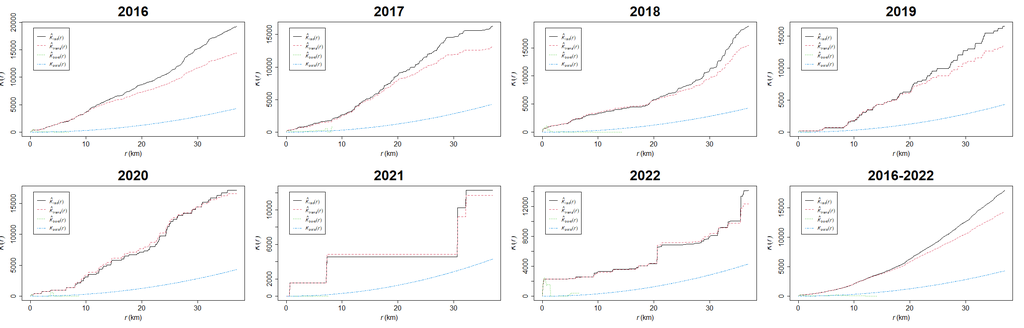

```r
par( mfrow= c(2,4) )
plot(Kest_ent16, main = "2016", cex.main = 3, cex.axis = 1.5, cex.lab = 1.5)
plot(Kest_ent17, main = "2017", cex.main = 3, cex.axis = 1.5, cex.lab = 1.5)
plot(Kest_ent18, main = "2018", cex.main = 3, cex.axis = 1.5, cex.lab = 1.5)
plot(Kest_ent19, main = "2019", cex.main = 3, cex.axis = 1.5, cex.lab = 1.5)
plot(Kest_ent20, main = "2020", cex.main = 3, cex.axis = 1.5, cex.lab = 1.5)
plot(Kest_ent21, main = "2021", cex.main = 3, cex.axis = 1.5, cex.lab = 1.5)
plot(Kest_ent22, main = "2022", cex.main = 3, cex.axis = 1.5, cex.lab = 1.5)
plot(Kest_ent, main = "2016-2022", cex.main = 3, cex.axis = 1.5, cex.lab = 1.5)
```

G function enteric fever - empirical function is greater than the theoretical (blue) suggest clustered pattern

```r
gestENT <- Gest(Enteric_kel.ppp2.km)
gestENT16 <- Gest(loc_ent16.ppp2.km)
gestENT17 <- Gest(loc_ent17.ppp2.km)
gestENT18 <- Gest(loc_ent18.ppp2.km)
gestENT19 <- Gest(loc_ent19.ppp2.km)
gestENT20 <- Gest(loc_ent20.ppp2.km)
gestENT21 <- Gest(loc_ent21.ppp2.km)
gestENT22 <- Gest(loc_ent22.ppp2.km)
```

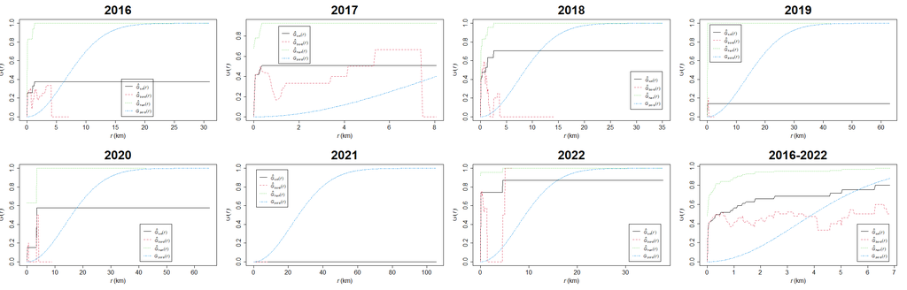

```r
par( mfrow= c(2,4) )
plot(gestENT16, main = "2016", cex.main = 3, cex.lab = 1.5, cex.axis = 1.5)
plot(gestENT17, main = "2017", cex.main = 3, cex.lab = 1.5, cex.axis = 1.5)
plot(gestENT18, main = "2018", cex.main = 3, cex.lab = 1.5, cex.axis = 1.5)
plot(gestENT19, main = "2019", cex.main = 3, cex.lab = 1.5, cex.axis = 1.5)
plot(gestENT20, main = "2020", cex.main = 3, cex.lab = 1.5, cex.axis = 1.5)
plot(gestENT21, main = "2021", cex.main = 3, cex.lab = 1.5, cex.axis = 1.5)
plot(gestENT22, main = "2022", cex.main = 3, cex.lab = 1.5, cex.axis = 1.5)
plot(gestENT, main = "2016-2022", cex.main = 3, cex.lab = 1.5, cex.axis = 1.5)
```

enveloped G function enteric fever 2016-2022

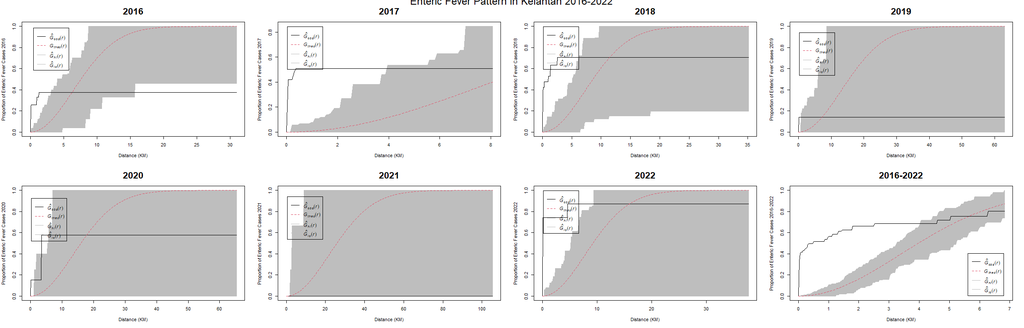

```r
# G function enteric fever per year
par( mfrow= c(2,4) )
GestENT16 <- plot(envelope(loc_ent16.ppp2.km, Gest, nsim = 99, verbose = FALSE), main = "2016",xlab = "Distance (KM)", ylab = "Proportion of Enteric Fever Cases 2016", cex.main = 2, cex.axis = 1, cex.lab = 1)
GestENT17 <- plot(envelope(loc_ent17.ppp2.km, Gest, nsim = 99, verbose = FALSE), main = "2017",xlab = "Distance (KM)", ylab = "Proportion of Enteric Fever Cases 2017", cex.main = 2, cex.axis = 1, cex.lab = 1)
GestENT18 <- plot(envelope(loc_ent18.ppp2.km, Gest, nsim = 99, verbose = FALSE), main = "2018",xlab = "Distance (KM)", ylab = "Proportion of Enteric Fever Cases 2018", cex.main = 2, cex.axis = 1, cex.lab = 1)
GestENT19 <- plot(envelope(loc_ent19.ppp2.km, Gest, nsim = 99, verbose = FALSE), main = "2019",xlab = "Distance (KM)", ylab = "Proportion of Enteric Fever Cases 2019", cex.main = 2, cex.axis = 1, cex.lab = 1)
GestENT20 <- plot(envelope(loc_ent20.ppp2.km, Gest, nsim = 99, verbose = FALSE), main = "2020",xlab = "Distance (KM)", ylab = "Proportion of Enteric Fever Cases 2020", cex.main = 2, cex.axis = 1, cex.lab = 1)
GestENT21 <- plot(envelope(loc_ent21.ppp2.km, Gest, nsim = 99, verbose = FALSE), main = "2021",xlab = "Distance (KM)", ylab = "Proportion of Enteric Fever Cases 2021", cex.main = 2, cex.axis = 1, cex.lab = 1)
GestENT22 <- plot(envelope(loc_ent22.ppp2.km, Gest, nsim = 99, verbose = FALSE), main = "2022",xlab = "Distance (KM)", ylab = "Proportion of Enteric Fever Cases 2022", cex.main = 2, cex.axis = 1, cex.lab = 1)
GestENT <- plot(envelope(Enteric_kel.ppp2.km, Gest, nsim = 99, verbose = FALSE), main = "2016-2022",xlab = "Distance (KM)", ylab = "Proportion of Enteric Fever Cases 2016-2022", cex.main = 2, cex.axis = 1, cex.lab = 1)

mtext("Enteric Fever Pattern in Kelantan 2016-2022", side = 3, line = -1, cex = 1.5, outer = TRUE)
```

F test for enteric fever - empirical values below theoretical (blue) suggest clustering

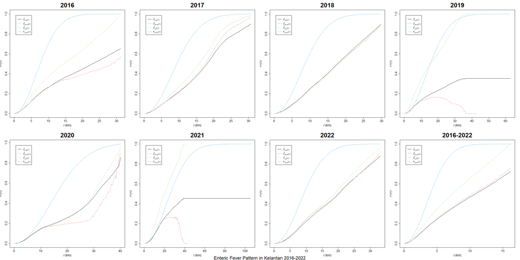

```r
par( mfrow= c(2,4) )
plot(Fest(loc_ent16.ppp2.km), main = "2016", cex.main = 3, cex.axis = 1.5, cex.lab = 1.5)
plot(Fest(loc_ent17.ppp2.km), main = "2017", cex.main = 3, cex.axis = 1.5, cex.lab = 1.5)
plot(Fest(loc_ent18.ppp2.km), main = "2018", cex.main = 3, cex.axis = 1.5, cex.lab = 1.5)
plot(Fest(loc_ent19.ppp2.km), main = "2019", cex.main = 3, cex.axis = 1.5, cex.lab = 1.5)
plot(Fest(loc_ent20.ppp2.km), main = "2020", cex.main = 3, cex.axis = 1.5, cex.lab = 1.5)
plot(Fest(loc_ent21.ppp2.km), main = "2021", cex.main = 3, cex.axis = 1.5, cex.lab = 1.5)
plot(Fest(loc_ent22.ppp2.km), main = "2022", cex.main = 3, cex.axis = 1.5, cex.lab = 1.5)
plot(Fest(Enteric_kel.ppp2.km), main = "2016-2022", cex.main = 3, cex.axis = 1.5, cex.lab = 1.5)

mtext("Enteric Fever Pattern in Kelantan 2016-2022", side = 1, line = -1, cex = 1.5, outer = TRUE)
```

# distance-based analysis for Leptospirosis

ANN and intensity for Leptospirosis 2016-2022

```r
LEPIntensity <- round(summary(lepto_kel.ppp2.km)$intensity, 3)
LEPANNkm <- round(mean(nndist(lepto_kel.ppp2.km)), 3)
LEPANN <- round(mean(nndist(lepto_kel.ppp2)), 3)

#Intensity by year
LEP16_Intensity <- round(summary(loc_lep16.ppp2.km)$intensity, 3) #2016
LEP17_Intensity <- round(summary(loc_lep17.ppp2.km)$intensity, 3) #2017
LEP18_Intensity <- round(summary(loc_lep18.ppp2.km)$intensity, 3) #2018
LEP19_Intensity <- round(summary(loc_lep19.ppp2.km)$intensity, 3) #2019
LEP20_Intensity <- round(summary(loc_lep20.ppp2.km)$intensity, 3) #2020
LEP21_Intensity <- round(summary(loc_lep21.ppp2.km)$intensity, 3) #2021
LEP22_Intensity <- round(summary(loc_lep22.ppp2.km)$intensity, 3) #2022

#ANN in meter by year
LEPANN16 <- round(mean(nndist(loc_lep16.ppp2)), 2)
LEPANN17 <- round(mean(nndist(loc_lep17.ppp2)), 2)
LEPANN18 <- round(mean(nndist(loc_lep18.ppp2)), 2)
LEPANN19 <- round(mean(nndist(loc_lep19.ppp2)), 2)
LEPANN20 <- round(mean(nndist(loc_lep20.ppp2)), 2)
LEPANN21 <- round(mean(nndist(loc_lep21.ppp2)), 2)
LEPANN22 <- round(mean(nndist(loc_lep22.ppp2)), 2)

#interpret spatial intensity
print(paste0("The average spatial intensity for Leptospirosis cases 2016-2022 is ", LEPIntensity, " cases per sq. km."))
```

```
## [1] "The average spatial intensity for Leptospirosis cases 2016-2022 is 0.073 cases per sq. km."
```

```r
print(paste0("The average spatial intensity for Leptospirosis cases 2016 is ", LEP16_Intensity, " cases per sq. km."))
```

```
## [1] "The average spatial intensity for Leptospirosis cases 2016 is 0.024 cases per sq. km."
```

```r
print(paste0("The average spatial intensity for Leptospirosis cases 2017 is ", LEP17_Intensity, " cases per sq. km."))
```

```
## [1] "The average spatial intensity for Leptospirosis cases 2017 is 0.01 cases per sq. km."
```

```r
print(paste0("The average spatial intensity for Leptospirosis cases 2018 is ", LEP18_Intensity, " cases per sq. km."))
```

```
## [1] "The average spatial intensity for Leptospirosis cases 2018 is 0.012 cases per sq. km."
```

```r
print(paste0("The average spatial intensity for Leptospirosis cases 2019 is ", LEP19_Intensity, " cases per sq. km."))
```

```
## [1] "The average spatial intensity for Leptospirosis cases 2019 is 0.006 cases per sq. km."
```

```r
print(paste0("The average spatial intensity for Leptospirosis cases 2020 is ", LEP20_Intensity, " cases per sq. km."))
```

```
## [1] "The average spatial intensity for Leptospirosis cases 2020 is 0.003 cases per sq. km."
```

```r
print(paste0("The average spatial intensity for Leptospirosis cases 2021 is ", LEP21_Intensity, " cases per sq. km."))
```

```
## [1] "The average spatial intensity for Leptospirosis cases 2021 is 0.003 cases per sq. km."
```

```r
print(paste0("The average spatial intensity for Leptospirosis cases 2022 is ", LEP22_Intensity, " cases per sq. km."))
```

```
## [1] "The average spatial intensity for Leptospirosis cases 2022 is 0.015 cases per sq. km."
```

```r
#interpret ANN
print(paste0("The mean nearest neighbor distance for Leptospirosis cases 2016-2022 is ", LEPANN, " m."))
```

```
## [1] "The mean nearest neighbor distance for Leptospirosis cases 2016-2022 is 906.577 m."
```

```r
print(paste0("The mean nearest neighbor distance for Leptospirosis cases 2016 is ", LEPANN16, " m."))
```

```
## [1] "The mean nearest neighbor distance for Leptospirosis cases 2016 is 1793.08 m."
```

```r
print(paste0("The mean nearest neighbor distance for Leptospirosis cases 2017 is ", LEPANN17, " m."))
```

```
## [1] "The mean nearest neighbor distance for Leptospirosis cases 2017 is 3282.28 m."
```

```r
print(paste0("The mean nearest neighbor distance for Leptospirosis cases 2018 is ", LEPANN18, " m."))
```

```
## [1] "The mean nearest neighbor distance for Leptospirosis cases 2018 is 2792.46 m."
```

```r
print(paste0("The mean nearest neighbor distance for Leptospirosis cases 2019 is ", LEPANN19, " m."))
```

```
## [1] "The mean nearest neighbor distance for Leptospirosis cases 2019 is 4385.3 m."
```

```r
print(paste0("The mean nearest neighbor distance for Leptospirosis cases 2020 is ", LEPANN20, " m."))
```

```
## [1] "The mean nearest neighbor distance for Leptospirosis cases 2020 is 7358.82 m."
```

```r
print(paste0("The mean nearest neighbor distance for Leptospirosis cases 2021 is ", LEPANN21, " m."))
```

```
## [1] "The mean nearest neighbor distance for Leptospirosis cases 2021 is 6394.2 m."
```

```r
print(paste0("The mean nearest neighbor distance for Leptospirosis cases 2022 is ", LEPANN22, " m."))
```

```
## [1] "The mean nearest neighbor distance for Leptospirosis cases 2022 is 2533.81 m."
```

result ANN +intensity for leptospirosis

```r
ANN_LEPr <- bind_rows(
  data.frame(Dataset = "2016-2022", ANN.m = LEPANN, Intensity.sq.km = LEPIntensity),
  data.frame(Dataset = "2016", ANN.m = LEPANN16, Intensity.sq.km = LEP16_Intensity),
  data.frame(Dataset = "2017", ANN.m = LEPANN17, Intensity.sq.km = LEP17_Intensity),
  data.frame(Dataset = "2018", ANN.m = LEPANN18, Intensity.sq.km = LEP18_Intensity),
  data.frame(Dataset = "2019", ANN.m = LEPANN19, Intensity.sq.km = LEP19_Intensity),
  data.frame(Dataset = "2020", ANN.m = LEPANN20, Intensity.sq.km = LEP20_Intensity),
  data.frame(Dataset = "2021", ANN.m = LEPANN21, Intensity.sq.km = LEP21_Intensity),
  data.frame(Dataset = "2022", ANN.m = LEPANN22, Intensity.sq.km = LEP22_Intensity)
)
ANN_LEPr # ANN+intensity in table
```

```
##     Dataset    ANN.m Intensity.sq.km
## 1 2016-2022  906.577           0.073
## 2      2016 1793.080           0.024
## 3      2017 3282.280           0.010
## 4      2018 2792.460           0.012
## 5      2019 4385.300           0.006
## 6      2020 7358.820           0.003
## 7      2021 6394.200           0.003
## 8      2022 2533.810           0.015
```

Calculate nearest neigbour index (NNI) for leptospirosis - NNI < 1 clustered, >1 dispersed

```r
nniLEP <- nni(lepto_kel)
nniLEP16 <- nni(loc_lep16)
nniLEP17 <- nni(loc_lep17)
nniLEP18 <- nni(loc_lep18)
nniLEP19 <- nni(loc_lep19)
nniLEP20 <- nni(loc_lep20)
nniLEP21 <- nni(loc_lep21)
nniLEP22 <- nni(loc_lep22)
NNI_LEP <- bind_rows(
  data.frame(Dataset = "lepto_kel", nniLEP),
  data.frame(Dataset = "loc_lep16", nniLEP16),
  data.frame(Dataset = "loc_lep17", nniLEP17),
  data.frame(Dataset = "loc_lep18", nniLEP18),
  data.frame(Dataset = "loc_lep19", nniLEP19),
  data.frame(Dataset = "loc_lep20", nniLEP20),
  data.frame(Dataset = "loc_lep21", nniLEP21),
  data.frame(Dataset = "loc_lep22", nniLEP22)
)
NNI_LEP
```

```
##     Dataset       NNI     z.score             p expected.mean.distance
## 1 lepto_kel 0.5066545 -31.3877109 2.977136e-216               1789.341
## 2 loc_lep16 0.5974538 -14.6318827  1.758528e-48               3001.196
## 3 loc_lep17 0.8069370  -4.6425708  3.441007e-06               4067.577
## 4 loc_lep18 0.6811086  -8.1163418  4.804463e-16               4099.872
## 5 loc_lep19 0.7605712  -4.5112102  6.445880e-06               5765.793
## 6 loc_lep20 1.0425996   0.5281551  5.973917e-01               7058.142
## 7 loc_lep21 0.9495579  -0.5948619  5.519358e-01               6733.872
## 8 loc_lep22 0.6918232  -8.9993010  2.271594e-19               3662.505
##   observed.mean.distance
## 1               906.5775
## 2              1793.0759
## 3              3282.2780
## 4              2792.4584
## 5              4385.2965
## 6              7358.8164
## 7              6394.2014
## 8              2533.8060
```

```r
# NNI < 1 clustered, >1 dispersed under CSR
```

clark evans test for Leptospirosis -R less than 1 indicates spatial clustering. The smaller the value of R, the greater the degree of clustering. mean centre and standard distance for Enteric fever

```r
CElep <- clarkevans.test(lepto_kel.ppp2)
CElep16 <- clarkevans.test(loc_lep16.ppp2)
CElep17 <-clarkevans.test(loc_lep17.ppp2)
CElep18 <-clarkevans.test(loc_lep18.ppp2)
CElep19 <-clarkevans.test(loc_lep19.ppp2)
CElep20 <-clarkevans.test(loc_lep20.ppp2)
CElep21 <-clarkevans.test(loc_lep21.ppp2)
CElep22 <-clarkevans.test(loc_lep22.ppp2)


tCElep <- data.frame(Dataset = "lepto_kel.ppp2",
                       TestStatistic = CElep$statistic,
                       PValue = CElep$p.value)
tCElep16 <- data.frame(Dataset = "loc_lep16.ppp2",
                       TestStatistic = CElep16$statistic,
                       PValue = CElep16$p.value)
tCElep17 <- data.frame(Dataset = "loc_lep17.ppp2",
                       TestStatistic = CElep17$statistic,
                       PValue = CElep17$p.value)
tCElep18 <- data.frame(Dataset = "loc_lep18.ppp2",
                       TestStatistic = CElep18$statistic,
                       PValue = CElep18$p.value)
tCElep19 <- data.frame(Dataset = "loc_lep19.ppp2",
                       TestStatistic = CElep19$statistic,
                       PValue = CElep19$p.value)
tCElep20 <- data.frame(Dataset = "loc_lep20.ppp2",
                       TestStatistic = CElep20$statistic,
                       PValue = CElep20$p.value)
tCElep21 <- data.frame(Dataset = "loc_lep21.ppp2",
                       TestStatistic = CElep21$statistic,
                       PValue = CElep21$p.value)
tCElep22 <- data.frame(Dataset = "loc_lep22.ppp2",
                       TestStatistic = CElep22$statistic,
                       PValue = CElep22$p.value)

CE_LEPr <- bind_rows(
  data.frame(Dataset = "lepto_kel", tCElep),
  data.frame(Dataset = "loc_lep16", tCElep16),
  data.frame(Dataset = "loc_lep17", tCElep17),
  data.frame(Dataset = "loc_lep18", tCElep18),
  data.frame(Dataset = "loc_lep19", tCElep19),
  data.frame(Dataset = "loc_lep20", tCElep20),
  data.frame(Dataset = "loc_lep21", tCElep21),
  data.frame(Dataset = "loc_lep22", tCElep22)
)
CE_LEPr
```

```
##         Dataset      Dataset.1 TestStatistic       PValue
## R...1 lepto_kel lepto_kel.ppp2     0.4903916 0.000000e+00
## R...2 loc_lep16 loc_lep16.ppp2     0.5541314 0.000000e+00
## R...3 loc_lep17 loc_lep17.ppp2     0.6710647 2.664535e-15
## R...4 loc_lep18 loc_lep18.ppp2     0.6042739 0.000000e+00
## R...5 loc_lep19 loc_lep19.ppp2     0.7024984 2.078245e-08
## R...6 loc_lep20 loc_lep20.ppp2     0.7756988 5.420943e-03
## R...7 loc_lep21 loc_lep21.ppp2     0.6411190 2.313728e-05
## R...8 loc_lep22 loc_lep22.ppp2     0.6290886 0.000000e+00
```

```r
# R less than 1 indicates spatial clustering. The smaller the value of R, the greater the degree of clustering.
```

mean center and standard distance for leptospirosis

```r
#calculate mean center (m) for leptospirosis
lepxy <- coords(lepto_kel.ppp2)
mclep <- summarize(lepxy, xmean = mean(x), ymean = mean(y))
mclep
```

```
##    xmean    ymean
## 1 461684 625028.8
```

```r
#calculate standard distance (m) for leptospirosis
sdlep <- sqrt(sum((lepxy[,1] - mclep[1])^2 + (lepxy[,2] - mclep[2])^2) / nrow(lepxy))
sdlep
```

```
## [1] 2445.108
```

```r
LEPMADTest16 <- mad.test(loc_lep16.ppp2.km, fun = Kest, nsim = 99, verbose = FALSE)
```

```r
LEPMADTest17 <- mad.test(loc_lep17.ppp2.km, fun = Kest, nsim = 99, verbose = FALSE)
```

```r
# MAD test took to long, not evaluated when rendering
LEPMADTest18 <- mad.test(loc_lep18.ppp2.km, fun = Kest, nsim = 99, verbose = FALSE)
```

```r
LEPMADTest19 <- mad.test(loc_lep19.ppp2.km, fun = Kest, nsim = 99, verbose = FALSE)
```

```r
LEPMADTest20 <- mad.test(loc_lep20.ppp2.km, fun = Kest, nsim = 99, verbose = FALSE)
```

```r
LEPMADTest21 <- mad.test(loc_lep21.ppp2.km, fun = Kest, nsim = 99, verbose = FALSE)
```

```r
LEPMADTest22 <- mad.test(loc_lep22.ppp2.km, fun = Kest, nsim = 99, verbose = FALSE)
```

```r
LEPMADTest <- mad.test(lepto_kel.ppp2.km, fun = Kest, nsim = 99, verbose = FALSE)
```

```r
MAD_lep16.df <- data.frame(Dataset = "loc_lep16.ppp2",
                       TestStatistic = LEPMADTest16$statistic,
                       PValue = LEPMADTest16$p.value)
MAD_lep17.df <- data.frame(Dataset = "loc_lep17.ppp2",
                       TestStatistic = LEPMADTest17$statistic,
                       PValue = LEPMADTest17$p.value)
MAD_lep18.df <- data.frame(Dataset = "loc_lep18.ppp2",
                       TestStatistic = LEPMADTest18$statistic,
                       PValue = LEPMADTest18$p.value)
MAD_lep19.df <- data.frame(Dataset = "loc_lep19.ppp2",
                       TestStatistic = LEPMADTest19$statistic,
                       PValue = LEPMADTest19$p.value)
MAD_lep20.df <- data.frame(Dataset = "loc_lep20.ppp2",
                       TestStatistic = LEPMADTest20$statistic,
                       PValue = LEPMADTest20$p.value)
MAD_lep21.df <- data.frame(Dataset = "loc_lep21.ppp2",
                       TestStatistic = LEPMADTest21$statistic,
                       PValue = LEPMADTest21$p.value)
MAD_lep22.df <- data.frame(Dataset = "loc_lep22.ppp2",
                       TestStatistic = LEPMADTest22$statistic,
                       PValue = LEPMADTest22$p.value)

#combine rows
MAD_LEP <- bind_rows(
  data.frame(Dataset = "2016", MAD_lep16.df),
  data.frame(Dataset = "2017", MAD_lep17.df),
  data.frame(Dataset = "2018", MAD_lep18.df),
  data.frame(Dataset = "2019", MAD_lep19.df),
  data.frame(Dataset = "2020", MAD_lep20.df),
  data.frame(Dataset = "2021", MAD_lep21.df),
  data.frame(Dataset = "2022", MAD_lep22.df)
)
MAD_LEP
```

K function leptospirosis

```r
KestLep16 <- Kest(loc_lep16.ppp2.km)
KestLep17 <- Kest(loc_lep17.ppp2.km)
KestLep18 <- Kest(loc_lep18.ppp2.km)
KestLep19 <- Kest(loc_lep19.ppp2.km)
KestLep20 <- Kest(loc_lep20.ppp2.km)
KestLep21 <- Kest(loc_lep21.ppp2.km)
KestLep22 <- Kest(loc_lep22.ppp2.km)
```

```r
KestLep <- Kest(lepto_kel.ppp2.km)
```

Plot K test - Empirical values greater than theoretical values suggest clustering. - significance already tested using MAD test + MC permutation

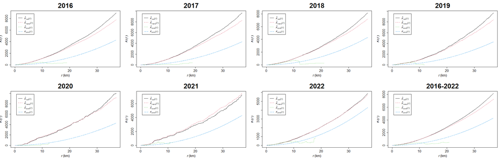

```r
par( mfrow= c(2,4) )
plot(KestLep16, main = "2016", cex.main = 3, cex.axis = 1.5, cex.lab = 1.5)
plot(KestLep17, main = "2017", cex.main = 3, cex.axis = 1.5, cex.lab = 1.5)
plot(KestLep18, main = "2018", cex.main = 3, cex.axis = 1.5, cex.lab = 1.5)
plot(KestLep19, main = "2019", cex.main = 3, cex.axis = 1.5, cex.lab = 1.5)
plot(KestLep20, main = "2020", cex.main = 3, cex.axis = 1.5, cex.lab = 1.5)
plot(KestLep21, main = "2021", cex.main = 3, cex.axis = 1.5, cex.lab = 1.5)
plot(KestLep22, main = "2022", cex.main = 3, cex.axis = 1.5, cex.lab = 1.5)
plot(KestLep, main = "2016-2022", cex.main = 3, cex.axis = 1.5, cex.lab = 1.5)
```

calculate G function for Leptospirosis

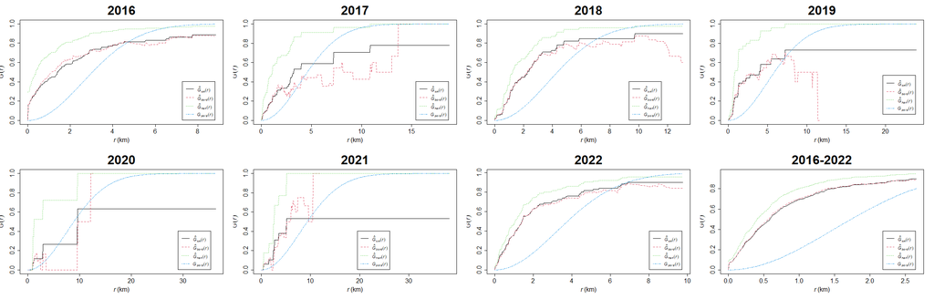

```r
# G function leptospirosis
par( mfrow= c(2,4) )
plot(Gest(loc_lep16.ppp2.km), main = "2016", cex.main = 3, cex.lab = 1.5, cex.axis = 1.5)
plot(Gest(loc_lep17.ppp2.km), main = "2017", cex.main = 3, cex.lab = 1.5, cex.axis = 1.5)
plot(Gest(loc_lep18.ppp2.km), main = "2018", cex.main = 3, cex.lab = 1.5, cex.axis = 1.5)
plot(Gest(loc_lep19.ppp2.km), main = "2019", cex.main = 3, cex.lab = 1.5, cex.axis = 1.5)
plot(Gest(loc_lep20.ppp2.km), main = "2020", cex.main = 3, cex.lab = 1.5, cex.axis = 1.5)
plot(Gest(loc_lep21.ppp2.km), main = "2021", cex.main = 3, cex.lab = 1.5, cex.axis = 1.5)
plot(Gest(loc_lep22.ppp2.km), main = "2022", cex.main = 3, cex.lab = 1.5, cex.axis = 1.5)
plot(Gest(lepto_kel.ppp2.km), main = "2016-2022", cex.main = 3, cex.lab = 1.5, cex.axis = 1.5)
```

Enveloped G function

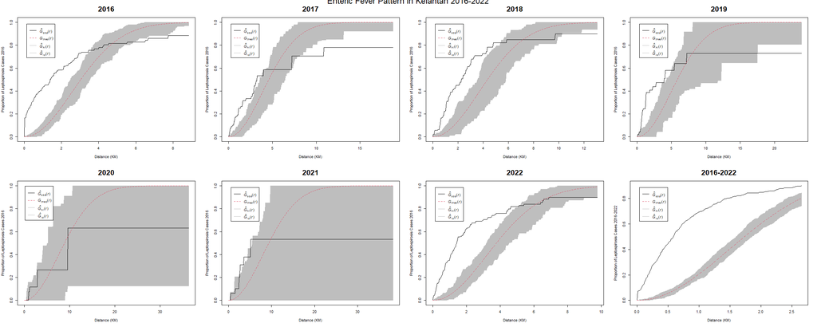

```r
# G function leptospirosis fever per year
par( mfrow= c(2,4) )
GestLEP16 <- plot(envelope(loc_lep16.ppp2.km, Gest, nsim = 99, verbose = FALSE), main = "2016",xlab = "Distance (KM)", ylab = "Proportion of Leptospirosis Cases 2016", cex.main = 2, cex.axis = 1, cex.lab = 1)
GestLEP17 <- plot(envelope(loc_lep17.ppp2.km, Gest, nsim = 99, verbose = FALSE), main = "2017",xlab = "Distance (KM)", ylab = "Proportion of Leptospirosis Cases 2016", cex.main = 2, cex.axis = 1, cex.lab = 1)
GestLEP18 <- plot(envelope(loc_lep18.ppp2.km, Gest, nsim = 99, verbose = FALSE), main = "2018",xlab = "Distance (KM)", ylab = "Proportion of Leptospirosis Cases 2016", cex.main = 2, cex.axis = 1, cex.lab = 1)
GestLEP19 <- plot(envelope(loc_lep19.ppp2.km, Gest, nsim = 99, verbose = FALSE), main = "2019",xlab = "Distance (KM)", ylab = "Proportion of Leptospirosis Cases 2016", cex.main = 2, cex.axis = 1, cex.lab = 1)
GestLEP20 <- plot(envelope(loc_lep20.ppp2.km, Gest, nsim = 99, verbose = FALSE), main = "2020",xlab = "Distance (KM)", ylab = "Proportion of Leptospirosis Cases 2016", cex.main = 2, cex.axis = 1, cex.lab = 1)
GestLEP21 <- plot(envelope(loc_lep21.ppp2.km, Gest, nsim = 99, verbose = FALSE), main = "2021",xlab = "Distance (KM)", ylab = "Proportion of Leptospirosis Cases 2016", cex.main = 2, cex.axis = 1, cex.lab = 1)
GestLEP22 <- plot(envelope(loc_lep22.ppp2.km, Gest, nsim = 99, verbose = FALSE), main = "2022",xlab = "Distance (KM)", ylab = "Proportion of Leptospirosis Cases 2016", cex.main = 2, cex.axis = 1, cex.lab = 1)
GestLEP <- plot(envelope(lepto_kel.ppp2.km, Gest, nsim = 99, verbose = FALSE), main = "2016-2022",xlab = "Distance (KM)", ylab = "Proportion of Leptospirosis Cases 2016-2022", cex.main = 2, cex.axis = 1, cex.lab = 1)

mtext("Enteric Fever Pattern in Kelantan 2016-2022", side = 3, line = -1, cex = 1.5, outer = TRUE)
```

F test of leptospirosis cases 2016-2022 - empirical values below theoretical (blue) suggest clustering

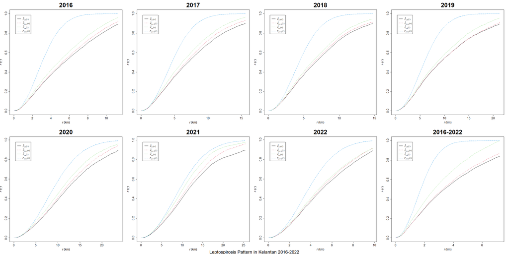

```r
par( mfrow= c(2,4) )
plot(Fest(loc_lep16.ppp2.km), main = "2016", cex.main = 3, cex.axis = 1.5, cex.lab = 1.5)
plot(Fest(loc_lep17.ppp2.km), main = "2017", cex.main = 3, cex.axis = 1.5, cex.lab = 1.5)
plot(Fest(loc_lep18.ppp2.km), main = "2018", cex.main = 3, cex.axis = 1.5, cex.lab = 1.5)
plot(Fest(loc_lep19.ppp2.km), main = "2019", cex.main = 3, cex.axis = 1.5, cex.lab = 1.5)
plot(Fest(loc_lep20.ppp2.km), main = "2020", cex.main = 3, cex.axis = 1.5, cex.lab = 1.5)
plot(Fest(loc_lep21.ppp2.km), main = "2021", cex.main = 3, cex.axis = 1.5, cex.lab = 1.5)
plot(Fest(loc_lep22.ppp2.km), main = "2022", cex.main = 3, cex.axis = 1.5, cex.lab = 1.5)
plot(Fest(lepto_kel.ppp2.km), main = "2016-2022", cex.main = 3, cex.axis = 1.5, cex.lab = 1.5)

mtext("Leptospirosis Pattern in Kelantan 2016-2022", side = 1, line = -1, cex = 1.5, outer = TRUE)
```

Clark Evans test for enteric fever using Monte Carlo (normal distribution not assumed)

```r
CE_entmc <- clarkevans.test(Enteric_kel.ppp2, nsim=99)
CE_ent16mc <- clarkevans.test(loc_ent16.ppp2, nsim=99)
CE_ent17mc <- clarkevans.test(loc_ent17.ppp2, nsim=99)
CE_ent18mc <- clarkevans.test(loc_ent18.ppp2, nsim=99)
CE_ent19mc <- clarkevans.test(loc_ent19.ppp2, nsim=99)
CE_ent20mc <- clarkevans.test(loc_ent20.ppp2, nsim=99)
CE_ent21mc <- clarkevans.test(loc_ent21.ppp2, nsim=99)
CE_ent22mc <- clarkevans.test(loc_ent22.ppp2, nsim=99)

# dataframe
CE_entmc.df <- data.frame(Dataset = "Enteric_kel.ppp2",
                       TestStatistic = CE_entmc$statistic,
                       PValue = CE_entmc$p.value)
CE_ent16mc.df <- data.frame(Dataset = "loc_ent16.ppp2",
                       TestStatistic = CE_ent16mc$statistic,
                       PValue = CE_ent16mc$p.value)
CE_ent17mc.df <- data.frame(Dataset = "loc_ent17.ppp2",
                       TestStatistic = CE_ent17mc$statistic,
                       PValue = CE_ent17mc$p.value)
CE_ent18mc.df <- data.frame(Dataset = "loc_ent18.ppp2",
                       TestStatistic = CE_ent18mc$statistic,
                       PValue = CE_ent18mc$p.value)
CE_ent19mc.df <- data.frame(Dataset = "loc_ent19.ppp2",
                       TestStatistic = CE_ent19mc$statistic,
                       PValue = CE_ent19mc$p.value)
CE_ent20mc.df <- data.frame(Dataset = "loc_ent20.ppp2",
                       TestStatistic = CE_ent20mc$statistic,
                       PValue = CE_ent20mc$p.value)
CE_ent21mc.df <- data.frame(Dataset = "loc_ent21.ppp2",
                       TestStatistic = CE_ent21mc$statistic,
                       PValue = CE_ent21mc$p.value)
CE_ent22mc.df <- data.frame(Dataset = "loc_ent22.ppp2",
                       TestStatistic = CE_ent22mc$statistic,
                       PValue = CE_ent22mc$p.value)

#combine rows
CE_ENTmc <- bind_rows(
  data.frame(Dataset = "2016-2022", CE_entmc.df),
  data.frame(Dataset = "2016", CE_ent16mc.df),
  data.frame(Dataset = "2017", CE_ent17mc.df),
  data.frame(Dataset = "2018", CE_ent18mc.df),
  data.frame(Dataset = "2019", CE_ent19mc.df),
  data.frame(Dataset = "2020", CE_ent20mc.df),
  data.frame(Dataset = "2021", CE_ent21mc.df),
  data.frame(Dataset = "2022", CE_ent22mc.df)
)
```

```r
CE_ENTmc
```

```
##         Dataset        Dataset.1 TestStatistic PValue
## R...1 2016-2022 Enteric_kel.ppp2     0.3891718   0.02
## R...2      2016   loc_ent16.ppp2     0.4751358   0.02
## R...3      2017   loc_ent17.ppp2     0.4515081   0.02
## R...4      2018   loc_ent18.ppp2     0.4216969   0.02
## R...5      2019   loc_ent19.ppp2     0.4404068   0.02
## R...6      2020   loc_ent20.ppp2     0.7830134   0.08
## R...7      2021   loc_ent21.ppp2     0.5183861   0.04
## R...8      2022   loc_ent22.ppp2     0.3621900   0.02
```

```r
CElepmc <- clarkevans.test(lepto_kel.ppp2)
CElep16mc <- clarkevans.test(loc_lep16.ppp2)
CElep17mc <-clarkevans.test(loc_lep17.ppp2)
CElep18mc <-clarkevans.test(loc_lep18.ppp2)
CElep19mc <-clarkevans.test(loc_lep19.ppp2)
CElep20mc <-clarkevans.test(loc_lep20.ppp2)
CElep21mc <-clarkevans.test(loc_lep21.ppp2)
CElep22mc <-clarkevans.test(loc_lep22.ppp2)


tCElepmc <- data.frame(Dataset = "lepto_kel.ppp2",
                       TestStatistic = CElepmc$statistic,
                       PValue = CElepmc$p.value)
tCElep16mc <- data.frame(Dataset = "loc_lep16.ppp2",
                       TestStatistic = CElep16mc$statistic,
                       PValue = CElep16mc$p.value)
tCElep17mc <- data.frame(Dataset = "loc_lep17.ppp2",
                       TestStatistic = CElep17mc$statistic,
                       PValue = CElep17mc$p.value)
tCElep18mc <- data.frame(Dataset = "loc_lep18.ppp2",
                       TestStatistic = CElep18mc$statistic,
                       PValue = CElep18mc$p.value)
tCElep19mc <- data.frame(Dataset = "loc_lep19.ppp2",
                       TestStatistic = CElep19mc$statistic,
                       PValue = CElep19mc$p.value)
tCElep20mc <- data.frame(Dataset = "loc_lep20.ppp2",
                       TestStatistic = CElep20mc$statistic,
                       PValue = CElep20mc$p.value)
tCElep21mc <- data.frame(Dataset = "loc_lep21.ppp2",
                       TestStatistic = CElep21mc$statistic,
                       PValue = CElep21mc$p.value)
tCElep22mc <- data.frame(Dataset = "loc_lep22.ppp2",
                       TestStatistic = CElep22mc$statistic,
                       PValue = CElep22mc$p.value)

CE_LEPrmc <- bind_rows(
  data.frame(Dataset = "lepto_kel", tCElepmc),
  data.frame(Dataset = "loc_lep16", tCElep16mc),
  data.frame(Dataset = "loc_lep17", tCElep17mc),
  data.frame(Dataset = "loc_lep18", tCElep18mc),
  data.frame(Dataset = "loc_lep19", tCElep19mc),
  data.frame(Dataset = "loc_lep20", tCElep20mc),
  data.frame(Dataset = "loc_lep21", tCElep21mc),
  data.frame(Dataset = "loc_lep22", tCElep22mc)
)
CE_LEPrmc
```

```
##         Dataset      Dataset.1 TestStatistic       PValue
## R...1 lepto_kel lepto_kel.ppp2     0.4903916 0.000000e+00
## R...2 loc_lep16 loc_lep16.ppp2     0.5541314 0.000000e+00
## R...3 loc_lep17 loc_lep17.ppp2     0.6710647 2.664535e-15
## R...4 loc_lep18 loc_lep18.ppp2     0.6042739 0.000000e+00
## R...5 loc_lep19 loc_lep19.ppp2     0.7024984 2.078245e-08
## R...6 loc_lep20 loc_lep20.ppp2     0.7756988 5.420943e-03
## R...7 loc_lep21 loc_lep21.ppp2     0.6411190 2.313728e-05
## R...8 loc_lep22 loc_lep22.ppp2     0.6290886 0.000000e+00
```